[figure not shown]

# 📢📢 DataMangueReport #1 - Despesas Orçamentárias 2017 📢📢

## Olá, Recifense arretado(a)!

### Você tem curiosidade em saber onde e como a Prefeitura do Recife está gastando nosso dinheiro?

Bem, então você está no lugar certo! Essa apresentação foi criada com esse intuito!

## Uma breve introdução

Devido a crise que vem assolando o Brasil nos últimos anos, muitos cidadãos estão pedindo **mudança!**  
O ano de 2018 foi marcado por uma eleição com diversas peculiaridades desde *fake news* até uma facada no presidente eleito.  
Mas eu pergunto a você, do que adianta votar, cobrar mudanças e não ACOMPANHAR onde nosso dinheiro vem sendo investido?  
Foi com esse pensamento que eu resolvi criar o DataMangueReport, um projeto independente sem nenhuma ligação partidaria, com o único e exclusivo objetivo de mostrar a sociedade de uma forma visual e narrada informações da gestão pública da capital pernambucana.

## Disclaimer

O *storytelling* usado nesse estudo foi aplicado com a proposta de permitir que qualquer pessoa possa conseguir compreender os dados plotados.

Se por acaso, você já tenha um conhecimento técnico em Python ou até mesmo em Data Science, por favor desconsidere alguns dos comentários que possam parecer insignificante, pelo fato de você já ter esse conhecimento.

Se você não entende de programação, se atente ao texto e aos gráficos gerados.

## Sobre este estudo

Nessa apresentação, estarei utilizando **dados abertos** disponibilizados pelo [Portal de Dados Abertos da Cidade do Recife](http://dados.recife.pe.gov.br/). Os dados escolhidos irão conter informações sobre os empenhos de todas as secretarias da Prefeitura de Recife no ano de 2017.

Dataset utilizado:

[recife-dados-despesas-2017.csv](http://dados.recife.pe.gov.br/dataset/despesas-orcamentarias/resource/d4d8a7f0-d4be-4397-b950-f0c991438111): possui os dados sobre cada empenho registrado em 2017.  
Tem interesse em receber uma análise como essa referente a **2018**?  
[CLIQUE AQUI](http://despesas.paginas.digital)

[output not shown]

[figure not shown]

# Dúvidas e Questionamentos

Dentre alguns *insights* criados durante o estudo, quero através dessa análise responder principalmente as seguintes perguntas:

> 1) Qual é a secretaria que apresenta a maior despesa?

> 2) Como é a distribuição das despesas da prefeitura durante o ano?

> 3) Quem é o credor que mais recebeu da prefeitura?

> 4) Qual é a representatividade dos empenhos que não foram nomeados?

> 5) Há divergências entre o valor do empenho e valor pago?

> 6) Qual a modalidade de licitação mais usada?

> 7) Dos gastos que não tiveram o credor identificado, qual foi a secretaria que teve maior representatividade?

> 8) Qual é o programa da prefeitura que tem maior despesa?

> 9) Qual é a fonte de recurso mais usada da prefeitura?

> 10) Com o que foi a maior despesa da prefeitura e pertence a qual secretaria?

> 11) Qual é a secretaria que fez mais empenhos?

> 12) Qual foi o maior empenho da prefeitura?

Tem **alguma pergunta** que você gostaria que fosse respondida **sobre esses dados que não está aqui?** Então, clica no botão a seguir, se increve e responde o primeiro e-mail que vou te enviar!

[MANDE SUA PERGUNTA](http://despesas.paginas.digital)

# Glossário

1) **Empenho**: É o primeiro estágio de um processo de pagamento da Administração Pública, pelo qual é feita a reserva de dotação orçamentária para um determinado fim, criando a obrigação de pagamento para o Estado. É uma garantia para o contratado de que existe recurso orçamentário (não financeiro) para liquidar aquela despesa.

# Importando as Bibliotecas

```python
import pandas as pd # Usado para criarmos DataFrames
import numpy as np # Usado para realizarmos cálculos matemáticos com melhor performance
import matplotlib.pyplot as plt # Usado para plotarmos gráficos
import random # Usado para gerar algo aleatoriamente
import benford as bf # Usado para realizar o estudo pela Lei de Benford

%matplotlib inline
```

# Definindo Cores

```python
# Definição das cores que iremos utilizar nos gráficos na etapa de visualização dos dados
cores  = [['#9c863a','#cfa81f','#efad3b','#d2952a','#e69a17'], # Mostarda
          ['#6a188c','#8d38b0','#9109c9','#873fa5','#82419d'], # Roxo
          ['#41873c','#2c6c27','#4d6f4b','#4f9a49','#209317'], # Verde
          ['#186fe6','#2166c4','#0e64d8','#327de4','#0d5cc9'], # Azul
          ['#2c8d7c','#1c7565','#50887e','#38c2aa','#1a8471']  # Ciano
         ]
```

# Leitura do Conjunto de Dados

```python
# Iniciando a leitura do arquivo
df = pd.read_csv('/Users/lucasfeitosa/Downloads/Prefeitura/Despesas/recife-dados-despesas-2017.csv', sep = ";")
```

```python
# Entendendo um pouco das dimensões do dataframe
print('O arquivo \"recife-dados-despesas-2017.csv\" contém ' + str(df.shape[0]) + ' linhas e ' + str(df.shape[1]) + ' colunas')
```

```
O arquivo "recife-dados-despesas-2017.csv" contém 94178 linhas e 39 colunas
```

# Data Wrangling (Limpeza de Dados)

```python
# Exibindo o dataframe como foi disponibilizado pelo Portal de Dados Abertos da Cidade do Recife
df.head(3)
```

|  | ano_movimentacao | mes_movimentacao | orgao_codigo | orgao_nome | unidade_codigo | unidade_nome | categoria_economica_codigo | categoria_economica_nome | grupo_despesa_codigo | grupo_despesa_nome | ... | empenho_numero | subempenho | indicador_subempenho | credor_codigo | credor_nome | modalidade_licitacao_codigo | modalidade_licitacao_nome | valor_empenhado | valor_liquidado | valor_pago |
| --- | --- | --- | --- | --- | --- | --- | --- | --- | --- | --- | --- | --- | --- | --- | --- | --- | --- | --- | --- | --- | --- |
| 0 | 2017 | 3 | 10 | GABINETE DO PREFEITO | 10.01 | GABINETE DO PREFEITO - ADMINISTRAÇÃO DIRETA | 3 | DESPESAS CORRENTES | 1 | PESSOAL E ENCARGOS SOCIAIS | ... | 43 | 83 | x | 0 | CREDOR NÃO INFORMADO | 0 | NÃO INFORMADA | 160613,59 | 160613,59 | 160613,59 |
| 1 | 2017 | 4 | 10 | GABINETE DO PREFEITO | 10.01 | GABINETE DO PREFEITO - ADMINISTRAÇÃO DIRETA | 3 | DESPESAS CORRENTES | 1 | PESSOAL E ENCARGOS SOCIAIS | ... | 43 | 84 | x | 0 | CREDOR NÃO INFORMADO | 0 | NÃO INFORMADA | 159933,78 | 159933,78 | 159933,78 |
| 2 | 2017 | 7 | 10 | GABINETE DO PREFEITO | 10.01 | GABINETE DO PREFEITO - ADMINISTRAÇÃO DIRETA | 3 | DESPESAS CORRENTES | 1 | PESSOAL E ENCARGOS SOCIAIS | ... | 43 | 87 | x | 0 | CREDOR NÃO INFORMADO | 0 | NÃO INFORMADA | 77521,68 | 77521,68 | 77521,68 |

3 rows × 39 columns

```python
# Verificando como os dados estão sendo reconhecidos pelo Pandas.
df.dtypes
```

```
ano_movimentacao                 int64
mes_movimentacao                 int64
orgao_codigo                     int64
orgao_nome                      object
unidade_codigo                 float64
unidade_nome                    object
categoria_economica_codigo       int64
categoria_economica_nome        object
grupo_despesa_codigo             int64
grupo_despesa_nome              object
modalidade_aplicacao_codigo      int64
modalidade_aplicacao_nome       object
elemento_codigo                  int64
elemento_nome                   object
subelemento_codigo               int64
subelemento_nome                object
funcao_codigo                    int64
funcao_nome                     object
subfuncao_codigo                 int64
subfuncao_nome                  object
programa_codigo                  int64
programa_nome                   object
acao_codigo                      int64
acao_nome                       object
fonte_recurso_codigo             int64
fonte_recurso_nome              object
empenho_ano                      int64
empenho_modalidade_nome         object
empenho_modalidade_codigo        int64
empenho_numero                   int64
subempenho                       int64
indicador_subempenho            object
credor_codigo                    int64
credor_nome                     object
modalidade_licitacao_codigo      int64
modalidade_licitacao_nome       object
valor_empenhado                 object
valor_liquidado                 object
valor_pago                      object
dtype: object
```

```python
# Listando todas as colunas disponiveis no dataframe
df.columns
```

```
Index(['ano_movimentacao', 'mes_movimentacao', 'orgao_codigo', 'orgao_nome',
       'unidade_codigo', 'unidade_nome', 'categoria_economica_codigo',
       'categoria_economica_nome', 'grupo_despesa_codigo',
       'grupo_despesa_nome', 'modalidade_aplicacao_codigo',
       'modalidade_aplicacao_nome', 'elemento_codigo', 'elemento_nome',
       'subelemento_codigo', 'subelemento_nome', 'funcao_codigo',
       'funcao_nome', 'subfuncao_codigo', 'subfuncao_nome', 'programa_codigo',
       'programa_nome', 'acao_codigo', 'acao_nome', 'fonte_recurso_codigo',
       'fonte_recurso_nome', 'empenho_ano', 'empenho_modalidade_nome',
       'empenho_modalidade_codigo', 'empenho_numero', 'subempenho',
       'indicador_subempenho', 'credor_codigo', 'credor_nome',
       'modalidade_licitacao_codigo', 'modalidade_licitacao_nome',
       'valor_empenhado', 'valor_liquidado', 'valor_pago'],
      dtype='object')
```

```python
# Ocultando colunas que não serão utilizada na análise
df.drop(['orgao_codigo','categoria_economica_codigo','grupo_despesa_codigo','modalidade_aplicacao_codigo',
         'elemento_codigo','subelemento_codigo','funcao_codigo','subfuncao_codigo','programa_codigo',
         'acao_codigo','fonte_recurso_codigo','empenho_modalidade_codigo','subempenho',
         'indicador_subempenho','credor_codigo','modalidade_licitacao_codigo','unidade_codigo',
         'unidade_nome','empenho_ano'], axis=1, inplace=True);
```

```python
df.shape
```

```
(94178, 20)
```

```python
df.columns = ['ANO','MES','ORGAO','CATEGORIA','GRUPO','MODALIDADE','ELEMENTO','SUBELEMENTO','FUNCAO',
              'SUBFUNCAO','PROGRAMA','ACAO','RECURSO','MODALIDADE_EMPENHO','N_EMPENHO','CREDOR','MODALIDADE_LICITACAO',
             'VALOR_EMPENHADO','VALOR_LIQUIDADO','VALOR_PAGO']
```

```python
# Substituindo a virgula por ponto
df['VALOR_PAGO'] = df['VALOR_PAGO'].apply(lambda x: x.replace(',','.'));
df['VALOR_EMPENHADO'] = df['VALOR_EMPENHADO'].apply(lambda x: x.replace(',','.'));
df['VALOR_LIQUIDADO'] = df['VALOR_LIQUIDADO'].apply(lambda x: x.replace(',','.'));
```

```python
# Modificando o tipo de formatação da coluna
df['VALOR_PAGO'] = df['VALOR_PAGO'].astype(np.float64)
df['VALOR_EMPENHADO'] = df['VALOR_EMPENHADO'].astype(np.float64)
df['VALOR_LIQUIDADO'] = df['VALOR_LIQUIDADO'].astype(np.float64)
```

```python
# Inserindo uma nova coluna para realizar contagem
df['CONTAGEM'] = 1
```

```python
# Mostrando o dataframe após a limpeza e tratamento
df.head()
```

|  | ANO | MES | ORGAO | CATEGORIA | GRUPO | MODALIDADE | ELEMENTO | SUBELEMENTO | FUNCAO | SUBFUNCAO | ... | ACAO | RECURSO | MODALIDADE_EMPENHO | N_EMPENHO | CREDOR | MODALIDADE_LICITACAO | VALOR_EMPENHADO | VALOR_LIQUIDADO | VALOR_PAGO | CONTAGEM |
| --- | --- | --- | --- | --- | --- | --- | --- | --- | --- | --- | --- | --- | --- | --- | --- | --- | --- | --- | --- | --- | --- |
| 0 | 2017 | 3 | GABINETE DO PREFEITO | DESPESAS CORRENTES | PESSOAL E ENCARGOS SOCIAIS | APLICAÇÕES DIRETAS | VENCIMENTOS E VANTAGENS FIXAS - PESSOAL CIVIL | VENCIMENTOS E SALÁRIOS | ADMINISTRAÇÃO | ADMINISTRAÇÃO GERAL | ... | ASSESSORAMENTO GOVERNAMENTAL | RECURSOS ORDINÁRIOS - NÃO VINCULADOS | SEM TIPO INFORMADO | 43 | CREDOR NÃO INFORMADO | NÃO INFORMADA | 160613.59 | 160613.59 | 160613.59 | 1 |
| 1 | 2017 | 4 | GABINETE DO PREFEITO | DESPESAS CORRENTES | PESSOAL E ENCARGOS SOCIAIS | APLICAÇÕES DIRETAS | VENCIMENTOS E VANTAGENS FIXAS - PESSOAL CIVIL | VENCIMENTOS E SALÁRIOS | ADMINISTRAÇÃO | ADMINISTRAÇÃO GERAL | ... | ASSESSORAMENTO GOVERNAMENTAL | RECURSOS ORDINÁRIOS - NÃO VINCULADOS | SEM TIPO INFORMADO | 43 | CREDOR NÃO INFORMADO | NÃO INFORMADA | 159933.78 | 159933.78 | 159933.78 | 1 |
| 2 | 2017 | 7 | GABINETE DO PREFEITO | DESPESAS CORRENTES | PESSOAL E ENCARGOS SOCIAIS | APLICAÇÕES DIRETAS | VENCIMENTOS E VANTAGENS FIXAS - PESSOAL CIVIL | VENCIMENTOS E SALÁRIOS | ADMINISTRAÇÃO | ADMINISTRAÇÃO GERAL | ... | ASSESSORAMENTO GOVERNAMENTAL | RECURSOS ORDINÁRIOS - NÃO VINCULADOS | SEM TIPO INFORMADO | 43 | CREDOR NÃO INFORMADO | NÃO INFORMADA | 77521.68 | 77521.68 | 77521.68 | 1 |
| 3 | 2017 | 11 | GABINETE DO PREFEITO | DESPESAS CORRENTES | PESSOAL E ENCARGOS SOCIAIS | APLICAÇÕES DIRETAS | VENCIMENTOS E VANTAGENS FIXAS - PESSOAL CIVIL | VENCIMENTOS E SALÁRIOS | ADMINISTRAÇÃO | ADMINISTRAÇÃO GERAL | ... | ASSESSORAMENTO GOVERNAMENTAL | RECURSOS ORDINÁRIOS - NÃO VINCULADOS | SEM TIPO INFORMADO | 43 | CREDOR NÃO INFORMADO | NÃO INFORMADA | 86559.28 | 86559.28 | 86559.28 | 1 |
| 4 | 2017 | 6 | GABINETE DO PREFEITO | DESPESAS CORRENTES | PESSOAL E ENCARGOS SOCIAIS | APLICAÇÕES DIRETAS | VENCIMENTOS E VANTAGENS FIXAS - PESSOAL CIVIL | INCORPORAÇÕES | ADMINISTRAÇÃO | ADMINISTRAÇÃO GERAL | ... | ASSESSORAMENTO GOVERNAMENTAL | RECURSOS ORDINÁRIOS - NÃO VINCULADOS | SEM TIPO INFORMADO | 44 | CREDOR NÃO INFORMADO | NÃO INFORMADA | 2855.30 | 2855.30 | 2855.30 | 1 |

5 rows × 21 columns

# Data Visualization (Visualização dos Dados)

Shoooow! Agora que o nosso conjunto de dados está limpo e tratado agora podemos gerar *insights* sobre eles!

A primeira pergunta que eu quero responder é:

## Qual foi a despesa total no ano de 2017 da Prefeitura do Recife?

```python
print('O valor total de despesas entre todas as pastas foi de R$ {:,.2f}.'.format(df['VALOR_PAGO'].sum()))
```

```
O valor total de despesas entre todas as pastas foi de R$ 4,189,450,811.08.
```

## Quais são as pastas subordinadas a Prefeitura e qual delas que realizou maior quantidade de empenhos?

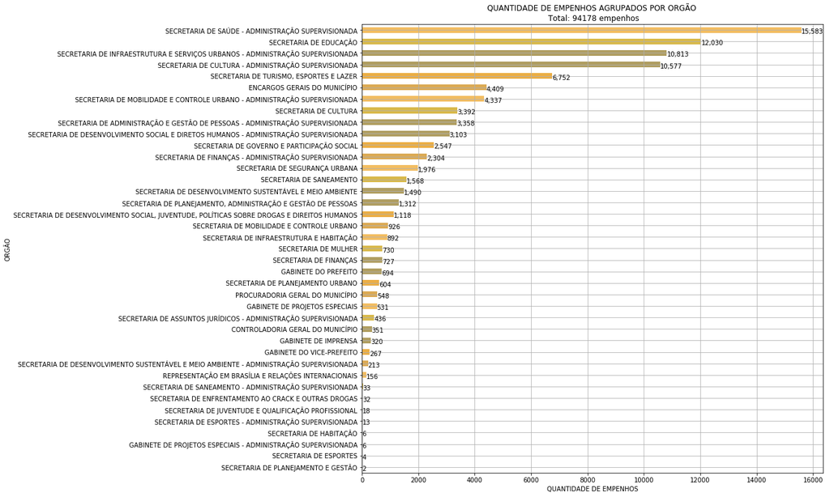

```python
count_orgao = df.groupby('ORGAO')['CONTAGEM'].sum().sort_values().plot(kind='barh', color=random.choice(cores), grid=True, figsize=(13,13), alpha=.8)

for p in count_orgao.patches:
    b=p.get_bbox()
    count_orgao.annotate("{:,.0f}".format(b.x1 + b.x0), (p.get_x() + p.get_width() + 1, p.get_y() - 0.05))

plt.title('QUANTIDADE DE EMPENHOS AGRUPADOS POR ORGÃO \n Total: ' + str(df['CONTAGEM'].sum()) + ' empenhos')
plt.ylabel('ORGÃO')
plt.xlabel('QUANTIDADE DE EMPENHOS')
plt.show()
```

Com base no conjunto de dados disponibilizado pela Prefeitura, podemos observar que a Prefeitura do Recife possui 39 pastas.  
E no ano de **2017** a pasta que mais emitiu notas de empenho foi a **SECRETARIA DE SAÚDE**, com um total de **15,583 empenhos**.

Você sabia disso?

Após classificarmos as pastas por empenhos... A pergunta é:

## Será que a secretaria que mais emitiu notas de empenho foi a que mais gastou dinheiro?

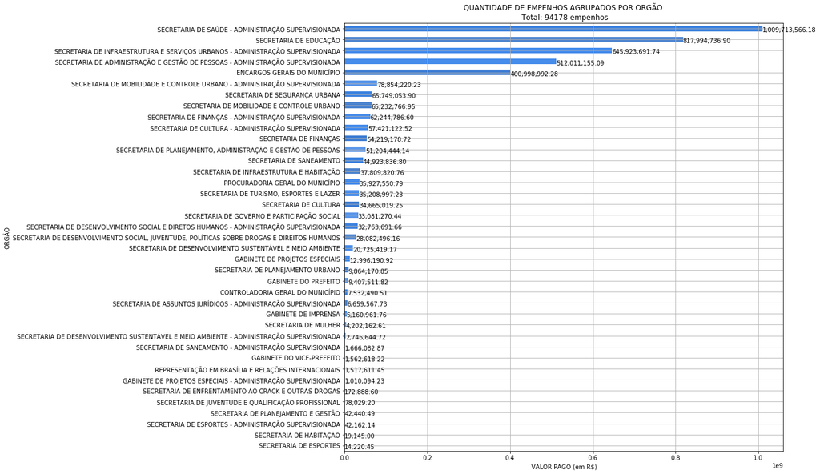

```python
sum_orgao_pago = df.groupby('ORGAO')['VALOR_PAGO'].sum().sort_values().plot(kind='barh', color=random.choice(cores), figsize=(13,13), grid=True, alpha=.8)

for p in sum_orgao_pago.patches:
    b=p.get_bbox()
    sum_orgao_pago.annotate("{:,.2f}".format(b.x1 + b.x0), (p.get_x() + p.get_width() + 1, p.get_y() - 0.05))

plt.title('QUANTIDADE DE EMPENHOS AGRUPADOS POR ORGÃO \n Total: ' + str(df['CONTAGEM'].sum()) + ' empenhos')
plt.ylabel('ORGÃO')
plt.xlabel('VALOR PAGO (em R$)')
plt.show()
```

Wow! Observamos que a **SECRETARIA DE SAÚDE** ainda se mantém NO TOPO das despesas da prefeitura chegando a custar pouco mais que **1 bilhão de reais** para os cofres públicos. 😲

Em seguida temos a:  
2) SECRETARIA DE EDUCAÇÃO  
3) SECRETARIA DE INFRAESTRUTURA E SERVIÇOS URBANOS  
4) SECRETARIA DE ADMINISTRAÇÃO E GESTÃO DE PESSOAS  
5) ENCARGOS GERAIS DO MUNICIPIO

## E como foi a distribuição dos empenhos durante os meses do ano?

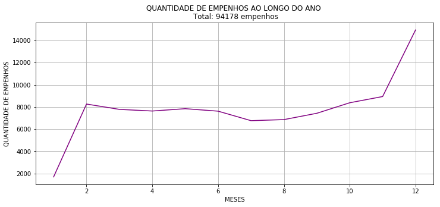

```python
df.groupby('MES')['CONTAGEM'].sum().plot(color='purple', figsize=(12,5), grid=True)

plt.title('QUANTIDADE DE EMPENHOS AO LONGO DO ANO \n Total: ' + str(df['CONTAGEM'].sum()) + ' empenhos')
plt.xlabel('MESES')
plt.ylabel('QUANTIDADE DE EMPENHOS')
plt.show()
```

## Como é a relação MENSAL entre os valores empenhados, liquidados e o realmente pago?

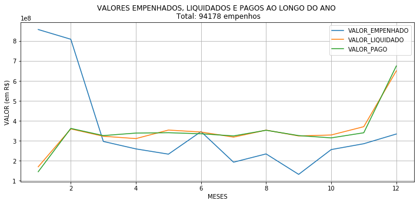

```python
df.groupby('MES')['VALOR_EMPENHADO','VALOR_LIQUIDADO','VALOR_PAGO'].sum().plot(figsize=(12,5), grid=True)

plt.title('VALORES EMPENHADOS, LIQUIDADOS E PAGOS AO LONGO DO ANO \n Total: ' + str(df['CONTAGEM'].sum()) + ' empenhos')
plt.xlabel('MESES')
plt.ylabel('VALOR (em R$)')
plt.show()
```

Segundo o Portal da Transparência do MS,

O **empenho** é o valor que o orgão público reserva para efetuar um pagamento planejado, podendo ocorrer após a assinatura de um contrato de prestação de serviço por exemplo. Quando cada serviço for executado o valor é **liquidado**, e quando o prestador de serviço receber o valor do serviço concluído este é considerado o valor **pago**.

## E como ficou no final do ano os valores empenhados, liquidados e pagos?

```python
print('Valor empenhado: R$ {:,.2f}.'.format(df['VALOR_EMPENHADO'].sum()))
print('Valor liquidado: R$ {:,.2f}.'.format(df['VALOR_LIQUIDADO'].sum()))
print('Valor pago: R$ {:,.2f}.'.format(df['VALOR_PAGO'].sum()))

em_aberto = df['VALOR_EMPENHADO'].sum() - df['VALOR_PAGO'].sum()
print('Valor em aberto aguardando pagamento: R$ {:,.2f}.'.format(em_aberto))
```

```
Valor empenhado: R$ 4,244,477,794.75.
Valor liquidado: R$ 4,215,833,518.64.
Valor pago: R$ 4,189,450,811.08.
Valor em aberto aguardando pagamento: R$ 55,026,983.67.
```

## Quais são as modalidades de pagamento utilizadas pela PCR?

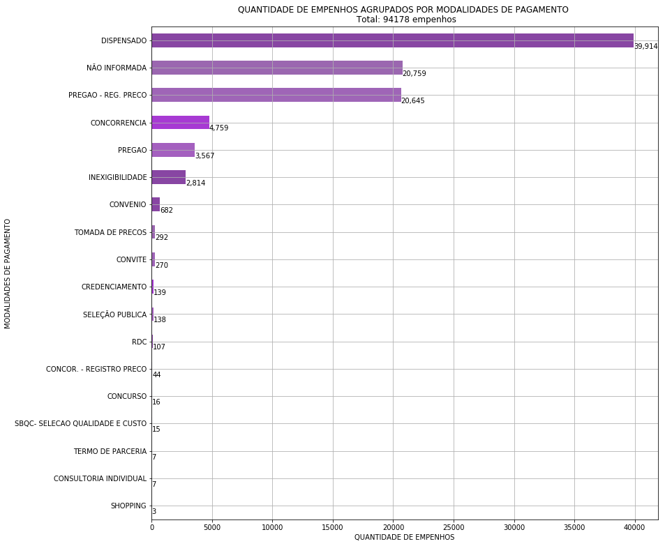

```python
count_licitacao = df.groupby('MODALIDADE_LICITACAO')['CONTAGEM'].sum().sort_values().plot(kind='barh', color=random.choice(cores), figsize=(13,13), grid=True,alpha=.8)

for p in count_licitacao.patches:
    b=p.get_bbox()
    count_licitacao.annotate("{:,.0f}".format(b.x1 + b.x0), (p.get_x() + p.get_width() + 1, p.get_y() - 0.05))

plt.title('QUANTIDADE DE EMPENHOS AGRUPADOS POR MODALIDADES DE PAGAMENTO \n Total: ' + str(df['CONTAGEM'].sum()) + ' empenhos')
plt.ylabel('MODALIDADES DE PAGAMENTO')
plt.xlabel('QUANTIDADE DE EMPENHOS')
plt.show()
```

Nesse gráfico a gente observa que a grande maioria dos pagamentos foram dispensados e/ou não informados. Algo que ao meu ver é preocupante.

```python
count_modalidade_disp = df[df['MODALIDADE_LICITACAO'] == "DISPENSADO"]
porcentagem_modalidade_disp = (count_modalidade_disp.count()/df.count())*100

print('{:.2f}% dos empenhos foram dispensados de concorrência.'.format(porcentagem_modalidade_disp[0]))
```

```
42.38% dos empenhos foram dispensados de concorrência.
```

```python
count_modalidade_nao_info = df[df['MODALIDADE_LICITACAO'] == "NÃO INFORMADA"]
porcentagem_modalidade_nao_info = (count_modalidade_nao_info.count()/df.count())*100

print('{:.2f}% dos empenhos não foram informados a modalidade de pagamento.'.format(porcentagem_modalidade_nao_info[0]))
```

```
22.04% dos empenhos não foram informados a modalidade de pagamento.
```

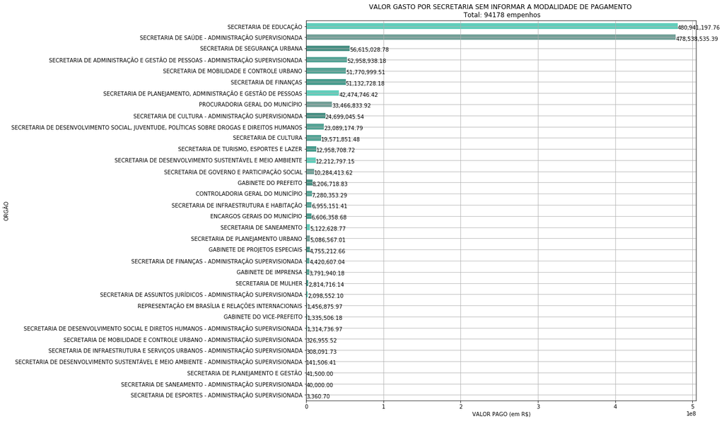

```python
sec_mod_lici = df[df['MODALIDADE_LICITACAO'] == "NÃO INFORMADA"]

sec_mod_lici_count_nao_info = sec_mod_lici.groupby('ORGAO')['VALOR_PAGO'].sum().sort_values().plot(kind='barh', color=random.choice(cores), grid=True, figsize=(13,13), alpha=.8)

for p in sec_mod_lici_count_nao_info.patches:
    b=p.get_bbox()
    sec_mod_lici_count_nao_info.annotate("{:,.2f}".format(b.x1 + b.x0), (p.get_x() + p.get_width() + 1, p.get_y() - 0.05))

plt.title('VALOR GASTO POR SECRETARIA SEM INFORMAR A MODALIDADE DE PAGAMENTO \n Total: ' + str(df['CONTAGEM'].sum()) + ' empenhos')
plt.ylabel('ORGÃO')
plt.xlabel('VALOR PAGO (em R$)')
plt.show()
```

Resumindo,

42,4% dos empenhos foram dispensados de qualquer tipo de concorrência.

22,0% dos empenhos não foram informados quanto a sua modalidade de pagamento.

E na modalidade de pagamento **NÃO INFORMADA** as duas secretarias que ficaram disparadamente na frente foi a **SECRETARIA DA EDUCAÇÃO** e a de **SAÚDE**, como podemos ver no gráfico acima. 😱

## E qual foi o maior empenho do ano?

```python
print('O maior empenho no ano de 2017 foi de R${:,.2f}.'.format(df['VALOR_PAGO'].max()))
```

```
O maior empenho no ano de 2017 foi de R$32,926,000.00.
```

```python
df.loc[df['VALOR_PAGO'] == df['VALOR_PAGO'].max()]
```

|  | ANO | MES | ORGAO | CATEGORIA | GRUPO | MODALIDADE | ELEMENTO | SUBELEMENTO | FUNCAO | SUBFUNCAO | ... | ACAO | RECURSO | MODALIDADE_EMPENHO | N_EMPENHO | CREDOR | MODALIDADE_LICITACAO | VALOR_EMPENHADO | VALOR_LIQUIDADO | VALOR_PAGO | CONTAGEM |
| --- | --- | --- | --- | --- | --- | --- | --- | --- | --- | --- | --- | --- | --- | --- | --- | --- | --- | --- | --- | --- | --- |
| 39655 | 2017 | 12 | ENCARGOS GERAIS DO MUNICÍPIO | DESPESAS CORRENTES | OUTRAS DESPESAS CORRENTES | APLICAÇÕES DIRETAS | OUTROS SERVIÇOS DE TERCEIROS - PESSOA JURÍDICA | INDENIZAÇÕES E RESTITUIÇÕES | ADMINISTRAÇÃO | ADMINISTRAÇÃO GERAL | ... | ENCARGOS GERAIS COMUNS AOS DIVERSOS ÓRGÃOS | RECURSOS ORDINÁRIOS - NÃO VINCULADOS | ORDINARIO | 806 | BANCO DO BRASIL S/A | DISPENSADO | 32926000.0 | 32926000.0 | 32926000.0 | 1 |

1 rows × 21 columns

Esse maior empenho foi feito pela pasta **ENCARGOS GERAIS DO MUNICIPIO** no valor de R$ 32,926,000.00 para o BANCO DO BRASIL S/A sendo caracterizado pelo subelemento como Indenizações e Restituições.

## Quem são os credores com maior quantidades de empenhos?

Para esse análise, eu considerei como referência, credores com número superior a 300 empenhos no ano.

```python
count_credor = df.groupby('CREDOR')['CONTAGEM'].sum().sort_values(ascending=False)
credores_mais_300 = count_credor[count_credor > 300]
credores_mais_300
```

```
CREDOR
CREDOR NÃO INFORMADO                                                                                           4722
CAIXA ECONOMICA FEDERAL                                                                                        2375
BANCO DO BRASIL S/A                                                                                            1582
R P L ENGENHARIA E SERVICOS LTDA                                                                               1539
BCA PROPAGANDA LTDA AGENCIA UM COMUNICACAO                                                                     1031
LOCADORA DE VEICULOS CAXANGA LTDA                                                                               790
SIND DAS EMP DE TRANSP DE PASSAG DO EST DE PERNAMBUCO - VEM - VALE ELETRONICO METROPOLITANO                     718
J & E LOCACAO E PRODUCAO DE EVENTOS LTDA EPP                                                                    649
SOLL SERVICOS OBRAS E LOCACOES LTDA                                                                             615
INSTITUTO EUVALDO LODI NUCLEO REG DE PERNAMBUCO IEL/PE                                                          604
INSTITUTO NACIONAL DE SEGURIDADE SOCIAL - INSS                                                                  595
COMPANHIA ENERGETICA DE PERNAMBUCO                                                                              586
TRIVALE ADMINISTRACAO LTDA                                                                                      568
TOPSERVICE TERCEIRIZACAO EIRELI                                                                                 558
MARIA JOAO EVENTOS EIRELI - EPP                                                                                 533
CLARO S/A                                                                                                       462
LUA PRODUCOES ARTISTICAS LTA ME                                                                                 444
COMPANHIA PERNAMBUCANA DE SANEAMENTO COMPESA                                                                    418
CLAUDIO F DE MORAES RAMOS EIRELE ME - L CORDEIRO                                                                417
LOQUIPE LOCACAO DE EQUIPAMENTOS E MAO DE OBRA LTDA                                                              411
DATA VOICE COMERCIO E SERVICOS LTDA                                                                             401
GUERRA CONSTRUCOES LTDA                                                                                         390
FUNDO FINANCEIRO - RECIFIN                                                                                      387
A J SERVICOS LTDA                                                                                               385
FUNCIONARIOS RELACIONADOS NA FOLHA DE PAGAMENTO DA AUTARQUIA DE TRANSITO E TRANSPORTE URBANO DO RECIFE CTTU     375
LOCAVEL SERVICOS LTDA                                                                                           371
FUNDO PREVIDENCIARIO - RECIPREV                                                                                 368
PETROCARD ADMINISTRADORA DE CREDITO LTDA                                                                        359
L & A PRODUCOES ARTISTICAS LTDA ME OXENTE PRODUCOES                                                             353
MC PRODUCOES PROMOCOES E EVENTOS CULTURAIS LTDA EPP                                                             345
WC LOCACAO E SERVICOS LTDA EPP                                                                                  343
SMART TELECOMUNICACOES E SERVICOS LTDA                                                                          340
GAMA EMPREENDIMENTOS CULTURAIS LTDA ME                                                                          328
GUSMAO PLANEJAMENTO E OBRAS LTDA                                                                                326
FUNCIONARIOS RELACIONADOS NA FOLHA DE PAGAMENTO DA EMPRESA DE MANUTENÇAO E LIMPEZA URBANA - EMLURB              324
BRASLUSO TURISMO LTDA EPP                                                                                       324
EMPRESA BRASILEIRA DE CORREIOS E TELEGRAFOS                                                                     322
SERVCAR LOCADORA EIRELI EPP                                                                                     310
Name: CONTAGEM, dtype: int64
```

Quer saber um pouco mais sobre essas empresa? (CNPJ, Sócios, CNAE, Endereço, Telefone)

Utilizei o [Empresas CNPJ](https://www.empresascnpj.com/) para fazer essa consulta:

[RPL Engenharia e Serviços LTD](https://www.empresascnpj.com/s/empresa/r-p-l-engenharia-e-servicos-ltda/01781573000162)  
[BCA PROPAGANDA LTDA AGENCIA UM COMUNICACAO](https://www.empresascnpj.com/s/empresa/bca-propaganda-ltda-nome-fantasia-agencia-um-comunicacao/03598189000154)  
[LOCADORA DE VEICULOS CAXANGA LTDA](https://www.empresascnpj.com/s/empresa/locadora-de-veiculos-caxanga-ltda/00329696000102)

**Comentário do autor:** O meu limite de consultas no site empresascnpj chegou ao fim, assim que for liberado irei incluir as outras empresas!

Quando analisamos a modalidade de pagamento, tiveram dados não informados! E o mesmo aconteceu com os credores, houveram algumas incidências de empenhos sem o nome do credor.  
E as secretarias que apresentaram uma GRANDE diferença das demais foram novamente a de **SAÚDE** e **EDUCAÇÃO**.

Fica a pergunta no ar... Por quê? 🤔

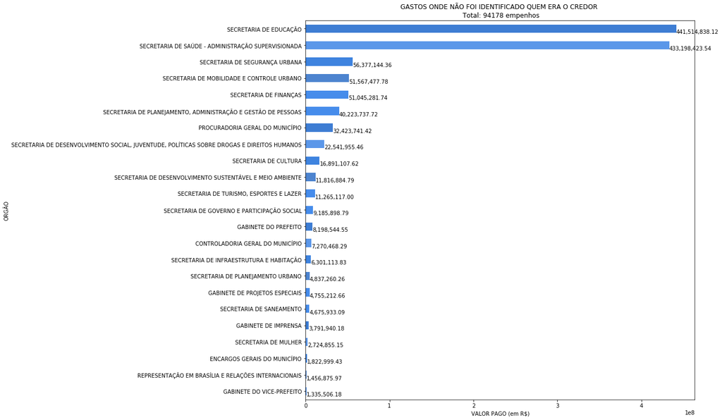

```python
cred_nao_info = df[df['CREDOR'] == "CREDOR NÃO INFORMADO"]

cred_nao_info_valor = cred_nao_info.groupby('ORGAO')['VALOR_PAGO'].sum().sort_values().plot(kind='barh', color=random.choice(cores), figsize=(13,13), alpha=.8)

for p in cred_nao_info_valor.patches:
    b=p.get_bbox()
    cred_nao_info_valor.annotate("{:,.2f}".format(b.x1 + b.x0), (p.get_x() + p.get_width() + 1, p.get_y() - 0.05))

plt.title('GASTOS ONDE NÃO FOI IDENTIFICADO QUEM ERA O CREDOR \n Total: ' + str(df['CONTAGEM'].sum()) + ' empenhos')
plt.ylabel('ORGÃO')
plt.xlabel('VALOR PAGO (em R$)')
plt.show()
```

A Prefeitura da Cidade do Recife possui em seu plano de gestão uma lista de programas. Você sabe quais são? E quais são os gastos de cada um deles?

## Quais são os programas da Prefeitura e quanto cada um gastou?

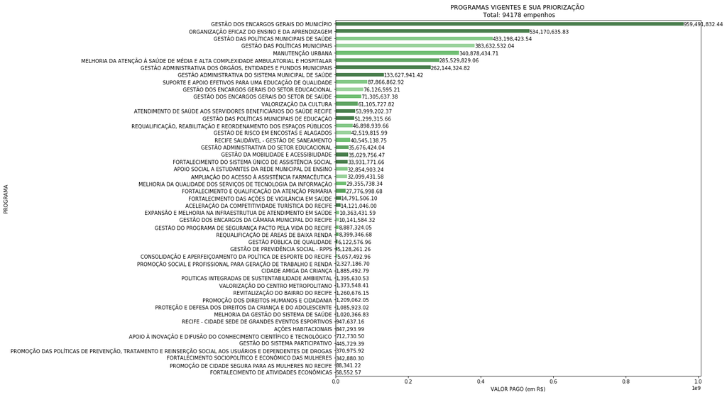

```python
count_programa = df.groupby('PROGRAMA')['VALOR_PAGO'].sum().sort_values().plot(kind='barh', color=['#1B5E20','#388E3C','#4CAF50','#81C784','#66BB6A'], figsize=(13,13), alpha=.8)

for p in count_programa.patches:
    b=p.get_bbox()
    count_programa.annotate("{:,.2f}".format(b.x1 + b.x0), (p.get_x() + p.get_width() + 1, p.get_y() - 0.05))

plt.title('PROGRAMAS VIGENTES E SUA PRIORIZAÇÃO \n Total: ' + str(df['CONTAGEM'].sum()) + ' empenhos')
plt.ylabel('PROGRAMA')
plt.xlabel('VALOR PAGO (em R$)')
plt.show()
```

É realmente triste olhar para os programas menos investidos e ver temas como:

1) Promoção de cidade segura para as mulheres no Recife  
2) Apoio a inovação e difusão do conhecimento científico e tecnológico  
3) Ações habitacionais  
4) Gestão do programa de segurança pacto pela vida do Recife

... entre o outros.

Bom, para pagar todas as despesas orçamentárias o dinheiro precisa sair de algum lugar e esse lugar é chamado pela Prefeitura de **recurso**. Você sabe...

## Quais são eles e quais são os mais usados?

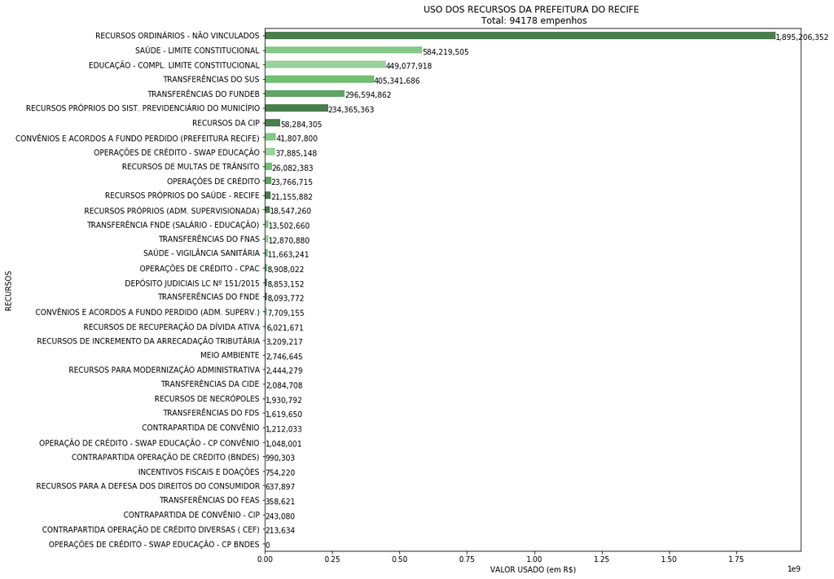

```python
count_recurso = df.groupby('RECURSO')['VALOR_PAGO'].sum().sort_values().plot(kind='barh', color=['#1B5E20','#388E3C','#4CAF50','#81C784','#66BB6A'], figsize=(13,13), alpha=.8)

for p in count_recurso.patches:
    b=p.get_bbox()
    count_recurso.annotate("{:,.0f}".format(b.x1 + b.x0), (p.get_x() + p.get_width() + 1, p.get_y() - 0.05))

plt.title('USO DOS RECURSOS DA PREFEITURA DO RECIFE \n Total: ' + str(df['CONTAGEM'].sum()) + ' empenhos')
plt.ylabel('RECURSOS')
plt.xlabel('VALOR USADO (em R$)')
plt.show()
```

# Especial: Lei de Benford, você conhece?

A **Lei de Benford** é um método utilizado amplamente para se verificar fraudes em conjuntos de dados!  
Essa lei estatística fala sobre a distribuição das frequências dos dígitos e pode ser utilizada em vários datasets da vida real, incluindo valores de ações, número de populações, imposto de rendas e entre outros...  
Bom, como sou curioso! Resolvi usar ela para correlacionar a distribuição dos números do primeiro dígito dos empenhos com a distribuição referência da Lei de Benford.

Vamos ver no que vai dar? 😆

**Recomendo a leitura:**  
[TCU - Aplicações da Lei de Benford à auditoria de obras públicas](https://portal.tcu.gov.br/inovatcu/noticias/aplicacoes-da-lei-de-benford-a-auditoria-de-obras-publicas.htm)  
[IME - Lei de Benford e aplicações](https://www.ime.usp.br/~abe/lista/pdfr6aqDSXtbC.pdf)

[figure not shown]

```python
# Criando colunas com os parâmetros para utilizar a biblioteca da lei de Benford
df['p_r'] = df.N_EMPENHO/df.N_EMPENHO.shift()-1
df['l_r'] = np.log(df.N_EMPENHO/df.N_EMPENHO.shift())
df.tail()
```

|  | ANO | MES | ORGAO | CATEGORIA | GRUPO | MODALIDADE | ELEMENTO | SUBELEMENTO | FUNCAO | SUBFUNCAO | ... | MODALIDADE_EMPENHO | N_EMPENHO | CREDOR | MODALIDADE_LICITACAO | VALOR_EMPENHADO | VALOR_LIQUIDADO | VALOR_PAGO | CONTAGEM | p_r | l_r |
| --- | --- | --- | --- | --- | --- | --- | --- | --- | --- | --- | --- | --- | --- | --- | --- | --- | --- | --- | --- | --- | --- |
| 94173 | 2017 | 5 | SECRETARIA DE INFRAESTRUTURA E HABITAÇÃO | DESPESAS CORRENTES | OUTRAS DESPESAS CORRENTES | APLICAÇÕES DIRETAS | OBRIGAÇÕES TRIBUTÁRIAS E CONTRIBUTIVAS | TAXAS | URBANISMO | SERVIÇOS URBANOS | ... | ORDINARIO | 120 | CAIXA ECONOMICA FEDERAL - AGENCIA CAIS DO APOL... | DISPENSADO | 420.00 | 420.00 | 0.00 | 1 | 2.750000 | 1.321756 |
| 94174 | 2017 | 8 | SECRETARIA DE INFRAESTRUTURA E HABITAÇÃO | DESPESAS CORRENTES | OUTRAS DESPESAS CORRENTES | APLICAÇÕES DIRETAS | OBRIGAÇÕES TRIBUTÁRIAS E CONTRIBUTIVAS | JUROS | URBANISMO | ADMINISTRAÇÃO GERAL | ... | ORDINARIO | 154 | CAIXA ECONOMICA FEDERAL - AGENCIA CAIS DO APOL... | DISPENSADO | 0.00 | 0.00 | 1203.09 | 1 | 0.283333 | 0.249461 |
| 94175 | 2017 | 9 | SECRETARIA DE INFRAESTRUTURA E HABITAÇÃO | DESPESAS CORRENTES | OUTRAS DESPESAS CORRENTES | APLICAÇÕES DIRETAS | OBRIGAÇÕES TRIBUTÁRIAS E CONTRIBUTIVAS | TAXAS | URBANISMO | SERVIÇOS URBANOS | ... | ORDINARIO | 193 | CAIXA ECONOMICA FEDERAL - AGENCIA CAIS DO APOL... | DISPENSADO | 60.00 | 60.00 | 0.00 | 1 | 0.253247 | 0.225738 |
| 94176 | 2017 | 10 | SECRETARIA DE INFRAESTRUTURA E HABITAÇÃO | DESPESAS CORRENTES | OUTRAS DESPESAS CORRENTES | APLICAÇÕES DIRETAS | OBRIGAÇÕES TRIBUTÁRIAS E CONTRIBUTIVAS | TAXAS | URBANISMO | SERVIÇOS URBANOS | ... | ORDINARIO | 193 | CAIXA ECONOMICA FEDERAL - AGENCIA CAIS DO APOL... | DISPENSADO | 0.00 | 0.00 | 60.00 | 1 | 0.000000 | 0.000000 |
| 94177 | 2017 | 11 | SECRETARIA DE FINANÇAS - ADMINISTRAÇÃO SUPERVI... | DESPESAS CORRENTES | OUTRAS DESPESAS CORRENTES | APLICAÇÕES DIRETAS | OUTROS SERVIÇOS DE TERCEIROS - PESSOA JURÍDICA | SERVIÇOS JUDICIÁRIOS | ADMINISTRAÇÃO | FORMAÇÃO DE RECURSOS HUMANOS | ... | ORDINARIO | 48 | PCR SESAN PCA 2 BBII | DISPENSADO | 5919.02 | 5919.02 | 0.00 | 1 | -0.751295 | -1.391489 |

5 rows × 23 columns

Ao gerar o gráfico correlacionado os dados de empenho da Prefeitura com a lei de Benford você tem a possibilidade de apontar um índices de confiabilidade entre 0 a 100%. Para o gráfico a seguir, eu escolhi 95% de confiabilidade.

```
Initialized sequence with 71385 registries.

Test performed on 71385 registries.
Discarded 0 records < 1 after preparation.

The entries with the significant positive deviations are:

             Expected     Found    Z_score
First_1_Dig
2            0.176091  0.198683  15.842140
1            0.301030  0.314044   7.575861
```

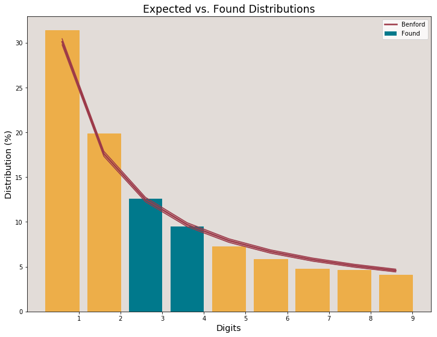

```python
# Setando os parâmetros para plotar o gráfico correlacionando benford e os dados de empenho.
f1d = bf.first_digits(df.l_r, digs=1, decimals=8, confidence=95)
```

Para a análise do primeiro dígito e com um índice de confiabilidade a 95% **apenas** os dígitos 3 e 4 corresponderam a lei. 😞

Levando em consideração que barras em amarelo nos alerta que aquele dígitos está fora da lei de Benford, podemos dizer que, nesse caso, o primeiro dígito está **78%** sem corresponder a lei.

## E se a gente fizer uma análise com o segundo?

```
Initialized sequence with 71385 registries.

Test performed on 71385 registries.
Discarded 0 records < 10 after preparation.

The entries with the significant positive deviations are:

         Expected     Found   Z_score
Sec_Dig
3         0.10433  0.107740  2.974457
8         0.08757  0.089739  2.043233
```

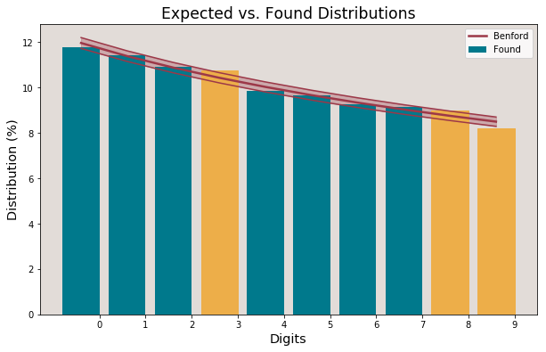

```python
sd = bf.second_digit(df.l_r, decimals=8, confidence=95)
```

Interessante! Com o segundo dígito e índice de confiabilidade a 95% o conjunto de dados já se apresenta muito mais confiável que o primeiro dígito.

Não sei você, mas minha curiosidade é grande... E agora te pergunto...

## E se a gente fizer a mesma análise com os dois últimos números?

```
Initialized sequence with 71385 registries.

Test performed on 71385 registries.
Discarded 0 records < 1000 after preparation

The entries with the significant positive deviations are:

            Expected     Found   Z_score
Last_2_Dig
55          0.010101  0.012804  7.202987
62          0.010101  0.011487  3.684577
73          0.010101  0.011053  2.524250
17          0.010101  0.010997  2.374530
18          0.010101  0.010941  2.224811
9           0.010101  0.010913  2.149951
```

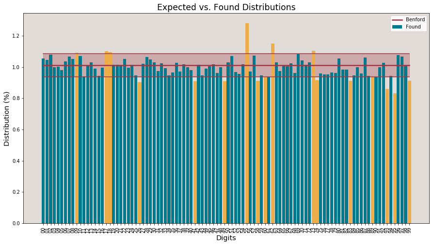

```python
l2d = bf.last_two_digits(df.l_r, decimals=8, confidence=95)
```

Incrível, como apenas o primeiro dígito apresentou uma alta porcentagem fora da lei de Benford.

Porque será? Alguém tem algum pitaco? 🤨

Uma outra análise que a lei de Benford pode nos proporcionar é a da **mantissa**.

Bom, mas o que é mantissa?

A mantissa é a parte decimal de um logaritmo.

Em um conjunto de dados de Benford, as mantissas dos registros são uniformemente distribuídas, de modo que, quando solicitadas, elas devem formar uma linha reta no intervalo.

```
The Mantissas MEAN is 0.41058487915252834. 		Ref: 0.5.
The Mantissas VARIANCE is 0.07200880999028093. 	Ref: 0.083333.
The Mantissas SKEWNESS is 0.361883713742848. 	Ref: 0.
The Mantissas KURTOSIS is -0.9099275287891455. 	Ref: -1.2.
```

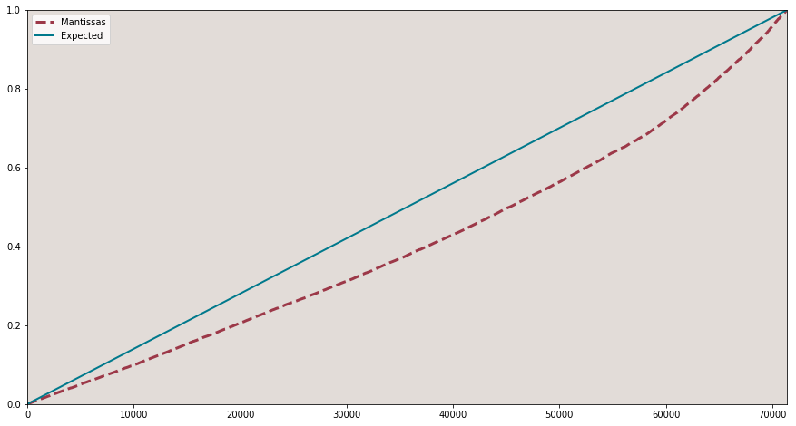

```python
mant = bf.mantissas(df.l_r, inform=True, show_plot=True)
```

Expectativa: Linha reta  
Realidade: Linha vermelha curvada e tracejada

# Conclusão

Espero que eu tenha conseguido entregar a proposta desse estudo através dessa narrativa. Um dos grandes principais objetivos desse projeto é mostrar que qualquer cidadão tem o poder de fiscalizar e com isso fazer questionamentos sobre os gastos públicos.  
Espero que tenha curtido esse DataMangueReport o tanto quanto eu. Se você ainda não é inscrito, clica no botão e tenha mensalmente estudos como esse.

[CLIQUE AQUI](http://despesas.paginas.digital)

Críticas e sugestões? [LinkedIn](http://www.linkedin.com/in/lucasfurtadofeitosa)  
Até mais!

# Referências

[Benford's Law](https://github.com/milcent/benford_py)  
[Christian Perone](http://blog.christianperone.com/2014/06/despesas-de-custeio-e-lei-de-benford/)  
[Portal Transparência MS](http://www.transparencia.al.ms.gov.br/pages/index.php/content/o-que-e-empenhado-liquidado-e-pago-na-execucao-orcamentaria)  
[Portal de Dados Abertos da Prefeitura de Recife](http://dados.recife.pe.gov.br)